# Blomning

I Sverige blommar körsbären i slutet av april till början av maj. Fruktträd såsom körsbär behöver en period med kalla temperaturer följt av en varm period för att sätta igång blomningen.

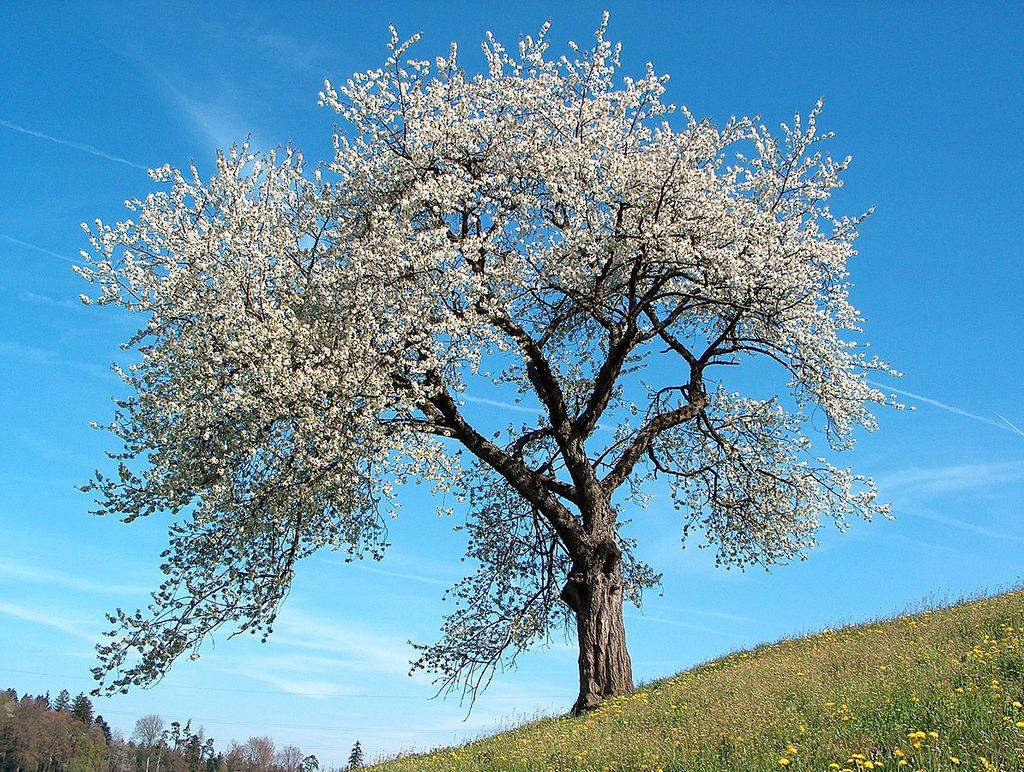

Blommande körsbärsträd. Fotograf Benjamin Gimmel.

För att en sort skall kunna pollinera en annan behöver de blomma samtidigt (givaren måste frisätta pollen under den period då mottagarens ägg är mottagligt). Ett körsbärsträd blommar vanligen 6-9 dagar. Varje enskild blomma är öppen i 3-5 dagar. De bästa förutsättningarna för befruktning är inom 2 dagar efter blomningens början. Efter 7 dagar är det ca 30% av blommorna som fortfarande kan befruktas hos de flesta sorter. Detta är temperaturberoende på så vis att svalare temperatur ger en mer långvarig period då blomman kan befruktas.

## När blommar det?

Tittar man på forskningsdata från Ullensvang i Norge startade blomningen där för sötkörsbär vanligen 6-14 maj (intervall 20 april till 22 maj beroende på år och sort). Blomningens varaktighet för ett körsbärsträd var där vanligen 9-16 dagar (intervall 7 till 19 dagar). Tar man med data från andra länder och justerar för odlingsplats och år ser man att för 80% av sorterna ligger start av blomningstiden inom ett spann på ca 9 dagar från varandra och blomningen varar 6-9 dagar.

Låga temperaturer kan fördröja start av blomningen, särskilt hos senblommande sorter. Faktorer som ålder, grundstam, närings- och vattentillgång, temperatur mm kan påverka varaktigheten av blomningen och det är tänkbart att olilka sorter påverkas olika av detta.

I Figure 1 visas skillnad i start av blomning för olika sorter (data från

[figure not shown]

). Värdet på tidsaxeln är antal dagar från den tidigaste sorten. Perioder på ca 3 dagars intervall är markerade.

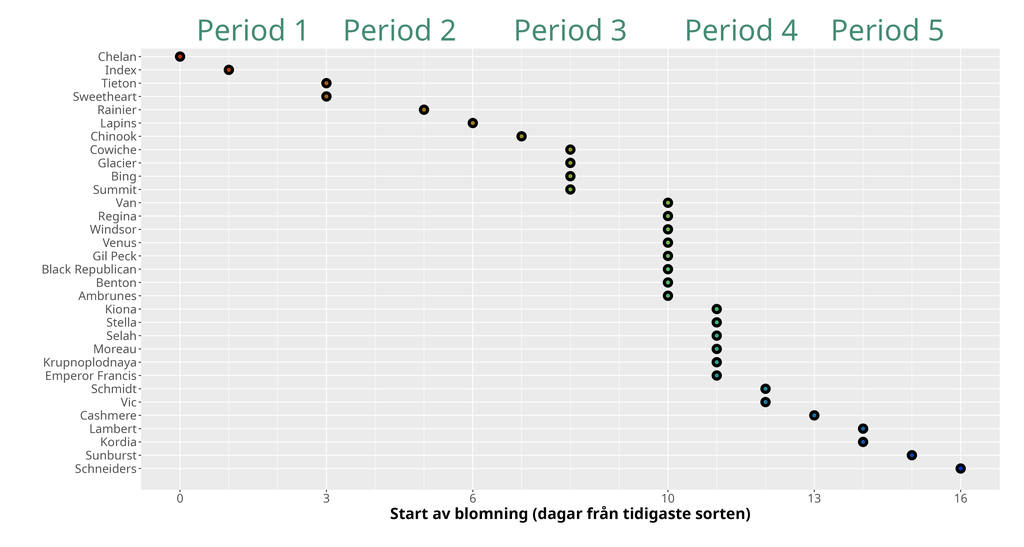

Figure 1: Start av blomning

## Risk för frost

Figuren nedan visar hur stor andel av åren 1991-2023 vars sista frost kom på eller innan ett visst datum. Exempel: Under 50 % av åren 1991-2023 inföll sista frosten före 9 maj, 75% före 14 maj, och 100% innan 28 maj. Det nedre, blå fältet visar fördelingen av datum för sista frost (inträffar ganska jämnt över perioden, men oftast kring 1 maj-17 maj). Temperaturdata från SMHI.

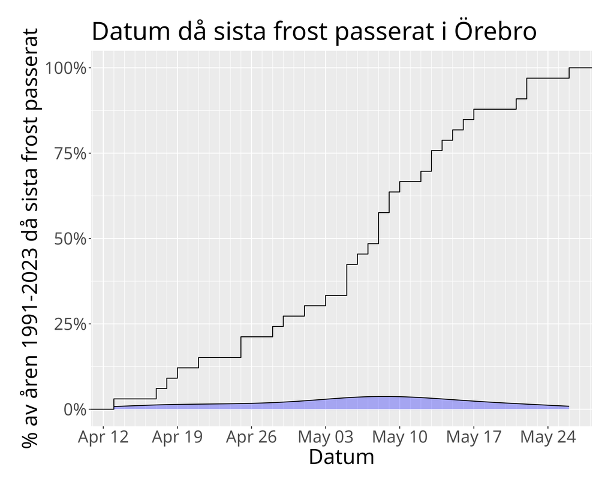

Figure 2: Andel (%) av år då frosten passerat, i Örebro.

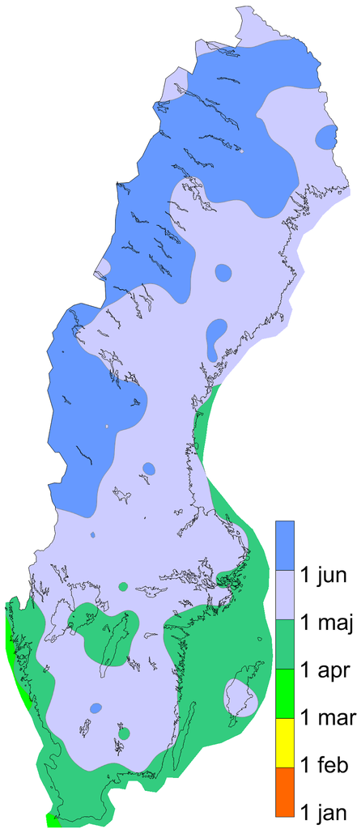

Sista frost